# Hurricane Data Analysis

Donghao Xue, Jingwen Xu

2020/11/10

## Backgroud

Last week, we completed the mapping about rainfall and hurricane track for certain hurricane. Now we got a dataset from FEMA(https://www.fema.gov/openfema-data-page/public-assistance-funded-projects-details-v1) about the public assistance funded projects details of all kinds of disaster such as severe storm, hurricane and so on. Now we will add these information to the map of hurricane distribution so that we can combine the damage and assistance information to have a deeper understanding of hurricane.

## The Hurricane Data Table

| disasterNumber | declarationDate | damageCategory | county | state | projectAmount | federalShareObligated | totalObligated |
| --- | --- | --- | --- | --- | --- | --- | --- |
| 1866 | 2009-12-22T05:00:00.000Z | Public Utilities | Mobile | Alabama | 0.00 | 0.00 | 0.00 |
| 1866 | 2009-12-22T05:00:00.000Z | Public Utilities | Mobile | Alabama | 58425.34 | 43819.01 | 43819.01 |
| 1866 | 2009-12-22T05:00:00.000Z | Public Utilities | Mobile | Alabama | 0.00 | 0.00 | 0.00 |
| 1866 | 2009-12-22T05:00:00.000Z | Public Utilities | Mobile | Alabama | 12778.47 | 9583.85 | 9583.85 |
| 1866 | 2009-12-22T05:00:00.000Z | Protective Measures | Mobile | Alabama | 15290.26 | 11467.70 | 11467.70 |
| 1866 | 2009-12-22T05:00:00.000Z | Protective Measures | Baldwin | Alabama | 9820.02 | 7365.02 | 7365.02 |

The table provides some information about the hurricane events in USA, such as:

- The declaration Date
- The name of county
- The cost of Public Assistance grant project
- The federal share obligated

## Mapping: The count of hurricane for each county

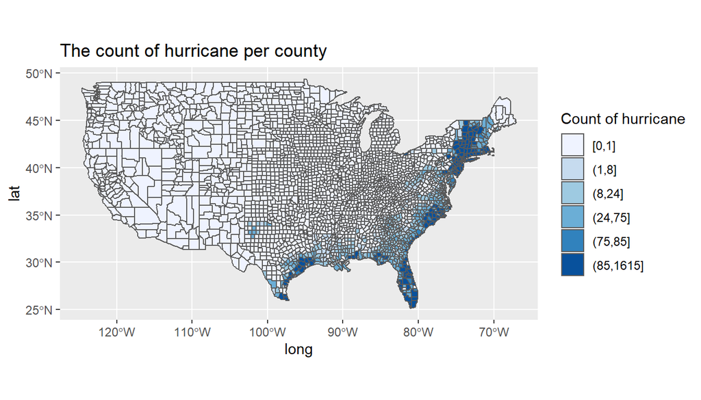

From the map we can see that hurricane happens mostly in the east coast.

## Mapping: The total public assistance cost for each county

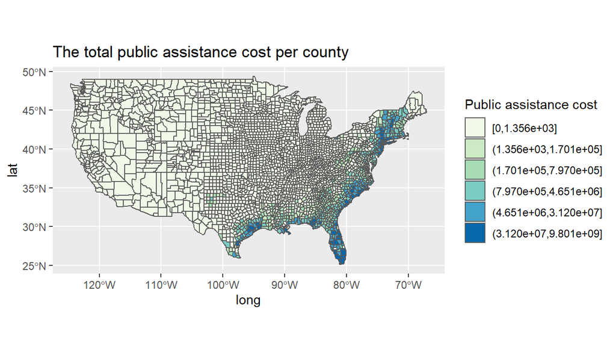

## Summary

```
##      Min.   1st Qu.    Median      Mean   3rd Qu.      Max.
## 1.356e+03 1.701e+05 7.970e+05 3.120e+07 4.651e+06 9.801e+09
```

From the summary we can see that the range of the data is very large. So the appropriate cut of the scale is important while mapping to show the data information clearly.

## Mapping: The total Federal Share Obligated for each county

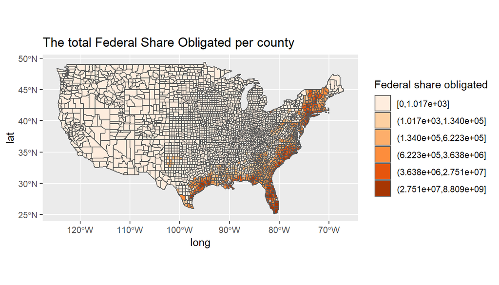

## Summmary

```
##      Min.   1st Qu.    Median      Mean   3rd Qu.      Max.
## 1.017e+03 1.340e+05 6.223e+05 2.751e+07 3.638e+06 8.809e+09
```

The data of federal share has a similar distribution with the data of public assistance cost and data about count of hurricane for each county. This is reasonable because the county with more frequent hurricane will need more public assistance and federal share obligated.